# Mental Health in the Workplace

Michelle Devine

2022-09-19

```r
library(knitr)
library(skimr)
library(ggplot2)
library(tidyverse)
library(dplyr)
```

## Mental Health in the Workplace Document.

**In this day and age mental health gets talked about more and more especially when it comes to the work place. People are feeling overwhelmed with not only work but also with aspects that go on outside the workplace. But how do you employees feel when it’s all become too much and they need help? Do employers provide employees the resources to get help? Are they punished for asking for help? Questions like these we hope to get some insight in from this dataset I used: click here https://www.kaggle.com/datasets/osmi/mental-health-in-tech-survey. This data is a bit outdated as it is from 2014. There is a continuation of this data from 2016 https://www.kaggle.com/datasets/osmi/mental-health-in-tech-2016**

Load the Data

```r
MH_in_tech <- read.csv("survey.csv")
```

```r
summary(MH_in_tech)
```

```
##   Timestamp              Age                Gender            Country
##  Length:1259        Min.   :-1.726e+03   Length:1259        Length:1259
##  Class :character   1st Qu.: 2.700e+01   Class :character   Class :character
##  Mode  :character   Median : 3.100e+01   Mode  :character   Mode  :character
##                     Mean   : 7.943e+07
##                     3rd Qu.: 3.600e+01
##                     Max.   : 1.000e+11
##     state           self_employed      family_history      treatment
##  Length:1259        Length:1259        Length:1259        Length:1259
##  Class :character   Class :character   Class :character   Class :character
##  Mode  :character   Mode  :character   Mode  :character   Mode  :character
##
##
##
##  work_interfere     no_employees       remote_work        tech_company
##  Length:1259        Length:1259        Length:1259        Length:1259
##  Class :character   Class :character   Class :character   Class :character
##  Mode  :character   Mode  :character   Mode  :character   Mode  :character
##
##
##
##    benefits         care_options       wellness_program    seek_help
##  Length:1259        Length:1259        Length:1259        Length:1259
##  Class :character   Class :character   Class :character   Class :character
##  Mode  :character   Mode  :character   Mode  :character   Mode  :character
##
##
##
##   anonymity            leave           mental_health_consequence
##  Length:1259        Length:1259        Length:1259
##  Class :character   Class :character   Class :character
##  Mode  :character   Mode  :character   Mode  :character
##
##
##
##  phys_health_consequence  coworkers          supervisor
##  Length:1259             Length:1259        Length:1259
##  Class :character        Class :character   Class :character
##  Mode  :character        Mode  :character   Mode  :character
##
##
##
##  mental_health_interview phys_health_interview mental_vs_physical
##  Length:1259             Length:1259           Length:1259
##  Class :character        Class :character      Class :character
##  Mode  :character        Mode  :character      Mode  :character
##
##
##
##  obs_consequence      comments
##  Length:1259        Length:1259
##  Class :character   Class :character
##  Mode  :character   Mode  :character
##
##
##
```

```r
skim_without_charts(MH_in_tech)
```

Data summary

| Name | MH_in_tech |
| --- | --- |
| Number of rows | 1259 |
| Number of columns | 27 |
| _______________________ |  |
| Column type frequency: |  |
| character | 26 |
| numeric | 1 |
| ________________________ |  |
| Group variables | None |

**Variable type: character**

| skim_variable | n_missing | complete_rate | min | max | empty | n_unique | whitespace |
| --- | --- | --- | --- | --- | --- | --- | --- |
| Timestamp | 0 | 1.00 | 19 | 19 | 0 | 1246 | 0 |
| Gender | 0 | 1.00 | 1 | 46 | 0 | 49 | 0 |
| Country | 0 | 1.00 | 5 | 22 | 0 | 48 | 0 |
| state | 515 | 0.59 | 2 | 2 | 0 | 45 | 0 |
| self_employed | 18 | 0.99 | 2 | 3 | 0 | 2 | 0 |
| family_history | 0 | 1.00 | 2 | 3 | 0 | 2 | 0 |
| treatment | 0 | 1.00 | 2 | 3 | 0 | 2 | 0 |
| work_interfere | 264 | 0.79 | 5 | 9 | 0 | 4 | 0 |
| no_employees | 0 | 1.00 | 3 | 14 | 0 | 6 | 0 |
| remote_work | 0 | 1.00 | 2 | 3 | 0 | 2 | 0 |
| tech_company | 0 | 1.00 | 2 | 3 | 0 | 2 | 0 |
| benefits | 0 | 1.00 | 2 | 10 | 0 | 3 | 0 |
| care_options | 0 | 1.00 | 2 | 8 | 0 | 3 | 0 |
| wellness_program | 0 | 1.00 | 2 | 10 | 0 | 3 | 0 |
| seek_help | 0 | 1.00 | 2 | 10 | 0 | 3 | 0 |
| anonymity | 0 | 1.00 | 2 | 10 | 0 | 3 | 0 |
| leave | 0 | 1.00 | 9 | 18 | 0 | 5 | 0 |
| mental_health_consequence | 0 | 1.00 | 2 | 5 | 0 | 3 | 0 |
| phys_health_consequence | 0 | 1.00 | 2 | 5 | 0 | 3 | 0 |
| coworkers | 0 | 1.00 | 2 | 12 | 0 | 3 | 0 |
| supervisor | 0 | 1.00 | 2 | 12 | 0 | 3 | 0 |
| mental_health_interview | 0 | 1.00 | 2 | 5 | 0 | 3 | 0 |
| phys_health_interview | 0 | 1.00 | 2 | 5 | 0 | 3 | 0 |
| mental_vs_physical | 0 | 1.00 | 2 | 10 | 0 | 3 | 0 |
| obs_consequence | 0 | 1.00 | 2 | 3 | 0 | 2 | 0 |
| comments | 1095 | 0.13 | 1 | 3548 | 0 | 160 | 1 |

**Variable type: numeric**

| skim_variable | n_missing | complete_rate | mean | sd | p0 | p25 | p50 | p75 | p100 |
| --- | --- | --- | --- | --- | --- | --- | --- | --- | --- |
| Age | 0 | 1 | 79428148 | 2818299443 | -1726 | 27 | 31 | 36 | 1e+11 |

```r
MH_in_tech$Age <- as.integer(MH_in_tech$Age)
```

**Now lets take a look.**

```r
summary(MH_in_tech)
```

```
##   Timestamp              Age              Gender            Country
##  Length:1259        Min.   :-1726.00   Length:1259        Length:1259
##  Class :character   1st Qu.:   27.00   Class :character   Class :character
##  Mode  :character   Median :   31.00   Mode  :character   Mode  :character
##                     Mean   :   30.78
##                     3rd Qu.:   36.00
##                     Max.   :  329.00
##                     NA's   :1
##     state           self_employed      family_history      treatment
##  Length:1259        Length:1259        Length:1259        Length:1259
##  Class :character   Class :character   Class :character   Class :character
##  Mode  :character   Mode  :character   Mode  :character   Mode  :character
##
##
##
##
##  work_interfere     no_employees       remote_work        tech_company
##  Length:1259        Length:1259        Length:1259        Length:1259
##  Class :character   Class :character   Class :character   Class :character
##  Mode  :character   Mode  :character   Mode  :character   Mode  :character
##
##
##
##
##    benefits         care_options       wellness_program    seek_help
##  Length:1259        Length:1259        Length:1259        Length:1259
##  Class :character   Class :character   Class :character   Class :character
##  Mode  :character   Mode  :character   Mode  :character   Mode  :character
##
##
##
##
##   anonymity            leave           mental_health_consequence
##  Length:1259        Length:1259        Length:1259
##  Class :character   Class :character   Class :character
##  Mode  :character   Mode  :character   Mode  :character
##
##
##
##
```

[output cut: 9 more lines]

```
##  Length:1259             Length:1259           Length:1259
##  Class :character        Class :character      Class :character
##  Mode  :character        Mode  :character      Mode  :character
##
##
##
##
##  obs_consequence      comments
##  Length:1259        Length:1259
##  Class :character   Class :character
##  Mode  :character   Mode  :character
##
##
##
##
```

This data set contains 1259 observations and 27 variables/columns.

*The variables are labeled as such:*

**Timestamp**

**Age**

**Gender**

**Country**

**state:** *If you live in the United States, which state or territory do you live in?*

**self_employed:** *Are you self-employed?*

**family_history:** *Do you have a family history of mental illness?*

**treatment:** *Have you sought treatment for a mental health condition?*

**work_interfere:** *If you have a mental health condition, do you feel that it interferes with your work?*

**no_employees:** *How many employees does your company or organization have?*

**remote_work:** *Do you work remotely (outside of an office) at least 50% of the time?*

**tech_company:** *Is your employer primarily a tech company/organization?*

**benefits:** *Does your employer provide mental health benefits?*

**care_options:** *Do you know the options for mental health care your employer provides?*

**wellness_program:** *Has your employer ever discussed mental health as part of an employee wellness program?*

**seek_help:** *Does your employer provide resources to learn more about mental health issues and how to seek help?*

**anonymity:** *Is your anonymity protected if you choose to take advantage of mental health or substance abuse treatment resources?*

**leave:** *How easy is it for you to take medical leave for a mental health condition?*

**mentalhealthconsequence:** *Do you think that discussing a mental health issue with your employer would have negative consequences?*

**physhealthconsequence:** *Do you think that discussing a physical health issue with your employer would have negative consequences?*

**coworkers:** *Would you be willing to discuss a mental health issue with your coworkers?*

**supervisor:** *Would you be willing to discuss a mental health issue with your direct supervisor(s)?*

**mentalhealthinterview:** *Would you bring up a mental health issue with a potential employer in an interview?*

**physhealthinterview:** *Would you bring up a physical health issue with a potential employer in an interview?*

**mentalvsphysical:** *Do you feel that your employer takes mental health as seriously as physical health?*

**obs_consequence:** *Have you heard of or observed negative consequences for coworkers with mental health conditions in your workplace?*

**comments:** *Any additional notes or comments*

**I decided to filter the data and just use the data from the United Sates seeing as it made up 751 of the observations, almost 60% of the dataset. With that kind of outlier graphing the data would be too skewed.**

*I used the code below tally how many observations are “United States.”*

```r
MH_in_tech%>%
  dplyr::group_by(Country == "United States")%>%
  tally()
```

```
## # A tibble: 2 × 2
##   `Country == "United States"`     n
##   <lgl>                        <int>
## 1 FALSE                          508
## 2 TRUE                           751
```

I wanted to make note, that the amount of participants working in tech were 1031 and the amount of non tech employees were 228. And among those who work in the United States, **611** work for a tech company while **140** do not.

```r
MH_in_tech%>%
  dplyr::group_by(Country == "United States", tech_company)%>%
  tally()
```

```
## # A tibble: 4 × 3
## # Groups:   Country == "United States" [2]
##   `Country == "United States"` tech_company     n
##   <lgl>                        <chr>        <int>
## 1 FALSE                        No              88
## 2 FALSE                        Yes            420
## 3 TRUE                         No             140
## 4 TRUE                         Yes            611
```

**I also wanted to make not that California seems to have a great stake in this data set than the other states. 138 of the responses from the United States came from California, making up 18.75% the total from the US. I filtered that by using the code below:**

```r
MH_in_tech%>%
  dplyr::group_by(state == "CA")%>%
  tally()
```

```
## # A tibble: 3 × 2
##   `state == "CA"`     n
##   <lgl>           <int>
## 1 FALSE             606
## 2 TRUE              138
## 3 NA                515
```

### Visualizations

A graph and table showing relation between variables “wellness program” and “state”:

```r
table(MH_in_tech$state,MH_in_tech$wellness_program)
```

```
##
##      Don't know No Yes
##   AL          1  6   1
##   AZ          0  5   2
##   CA         33 69  36
##   CO          1  7   1
##   CT          0  3   1
##   DC          0  3   1
##   FL          2 11   2
##   GA          2  6   4
##   IA          1  3   0
##   ID          0  1   0
##   IL          3 18   8
##   IN          2 19   6
##   KS          0  2   1
##   KY          0  3   2
##   LA          0  1   0
##   MA          7 11   2
##   MD          1  4   3
##   ME          0  1   0
##   MI          4 15   3
##   MN          6 11   4
##   MO          3  8   1
##   MS          0  1   0
##   NC          0 10   4
##   NE          1  0   1
##   NH          0  2   1
##   NJ          1  4   1
##   NM          1  1   0
##   NV          0  3   0
##   NY         11 32  14
##   OH          0 26   4
##   OK          2  3   1
##   OR          8 16   5
##   PA          5 18   6
##   RI          1  0   0
##   SC          0  3   2
##   SD          1  1   1
##   TN          7 28  10
##   TX          6 35   3
##   UT          1  8   2
##   VA          3  8   3
##   VT          1  2   0
##   WA         12 30  28
##   WI          0  9   3
##   WV          0  1   0
##   WY          0  2   0
```

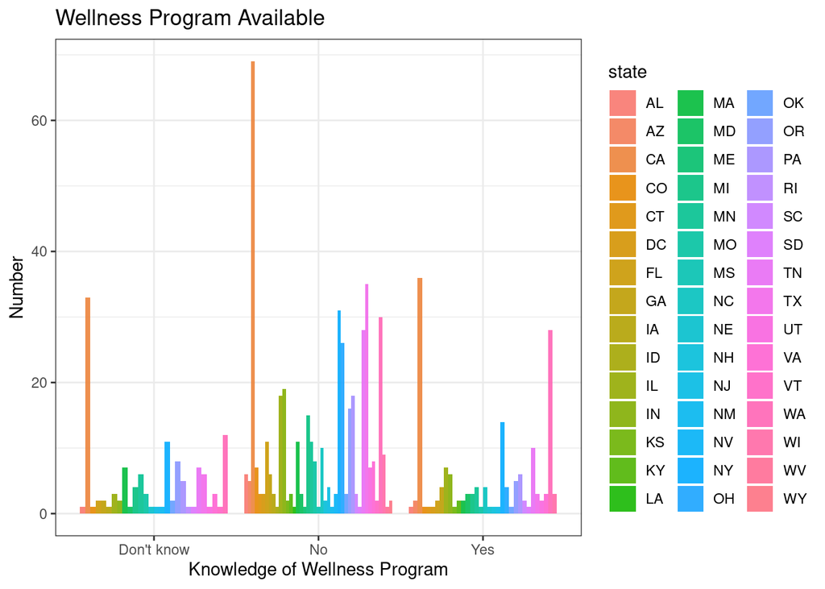

```r
MH_in_tech%>%
  filter(Country == "United States") %>%
  drop_na(state) %>%
  ggplot(aes(wellness_program, fill = state))+
  geom_bar(position= "dodge", alpha = 0.89)  +
  theme_bw() + labs(title = "Wellness Program Available", x = "Knowledge of Wellness Program", y = "Number")
```

**YES=167 NO=455 DON’T KNOW=129**

From the data above it shows that a little more than **60%** of employers in the US did not discuss mental health as a part of a their wellness program. That’s not to say that they don’t see it as important but it could be a tell that employers may not necessarily see it as a priority.

**A graph and table showing the relation between variables “seek help” and “state”:**

```r
table(MH_in_tech$state,MH_in_tech$seek_help)
```

```
##
##      Don't know No Yes
##   AL          1  6   1
##   AZ          1  5   1
##   CA         49 46  43
##   CO          5  2   2
##   CT          1  2   1
##   DC          0  3   1
##   FL          3  8   4
##   GA          5  2   5
##   IA          3  1   0
##   ID          1  0   0
##   IL          7 14   8
##   IN          8 13   6
##   KS          1  2   0
##   KY          3  1   1
##   LA          0  1   0
##   MA          8 10   2
##   MD          4  4   0
##   ME          0  1   0
##   MI          7 13   2
##   MN          9  7   5
##   MO          7  4   1
##   MS          0  1   0
##   NC          6  5   3
##   NE          1  0   1
##   NH          1  1   1
##   NJ          2  3   1
##   NM          1  1   0
##   NV          1  2   0
##   NY         18 23  16
##   OH          4 21   5
##   OK          3  2   1
##   OR         10  7  12
##   PA         14  8   7
##   RI          0  1   0
##   SC          4  0   1
##   SD          0  1   2
##   TN         19 17   9
##   TX         20 18   6
##   UT          1  6   4
##   VA          6  4   4
##   VT          2  1   0
##   WA         21 21  28
##   WI          1  6   5
##   WV          0  1   0
##   WY          1  1   0
```

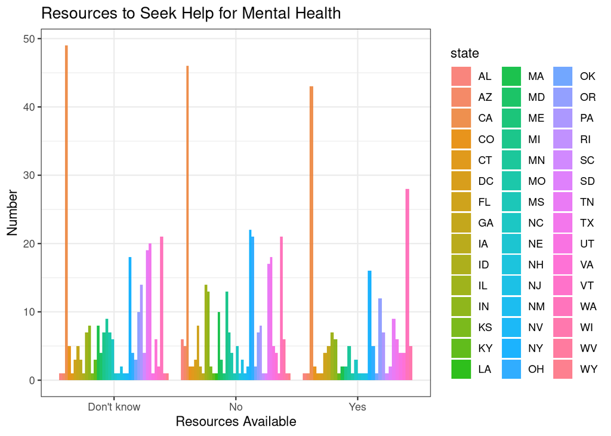

```r
MH_in_tech%>%
  filter(Country == "United States") %>%
  drop_na(state) %>%
  ggplot(aes(seek_help, fill = state))+
  geom_bar(position= "dodge", alpha = 0.89)  +
  theme_bw()+ labs(title = "Resources to Seek Help for Mental Health", x = "Resources Available", y = "Number")
```

**YES=189 NO=300 DON’T KNOW=262** Almost **40%** of employees in the United States went on record to say that their employers does not provided resources about mental health or in seeking help, while almost **35%** don’t know whether their employers provide these resources. Not knowing or not having the resources provided by your employer does not make it impossible to seek or get help, but it may be a factor when trying to get affordable help.

**A graph and table in relation to the variable “Mental Health Consequence” and “state”:**

```r
table(MH_in_tech$state,MH_in_tech$mental_health_consequence)
```

```
##
##      Maybe No Yes
##   AL     4  3   1
##   AZ     5  1   1
##   CA    57 47  34
##   CO     5  4   0
##   CT     0  2   2
##   DC     2  2   0
##   FL     8  6   1
##   GA     5  5   2
##   IA     2  1   1
##   ID     0  0   1
##   IL    14  9   6
##   IN     9 16   2
##   KS     2  1   0
##   KY     4  1   0
##   LA     0  0   1
##   MA     8  9   3
##   MD     3  3   2
##   ME     1  0   0
##   MI     9  8   5
##   MN     6 13   2
##   MO     4  4   4
##   MS     0  0   1
##   NC     6  4   4
##   NE     1  1   0
##   NH     2  0   1
##   NJ     3  2   1
##   NM     2  0   0
##   NV     1  1   1
##   NY    22 25  10
##   OH    13  8   9
##   OK     2  2   2
##   OR     7 17   5
##   PA    11 13   5
##   RI     0  1   0
##   SC     2  2   1
##   SD     0  1   2
##   TN    19 15  11
##   TX    16 13  15
##   UT     6  3   2
##   VA     5  5   4
##   VT     2  0   1
##   WA    28 21  21
##   WI     3  6   3
##   WV     0  0   1
##   WY     0  1   1
```

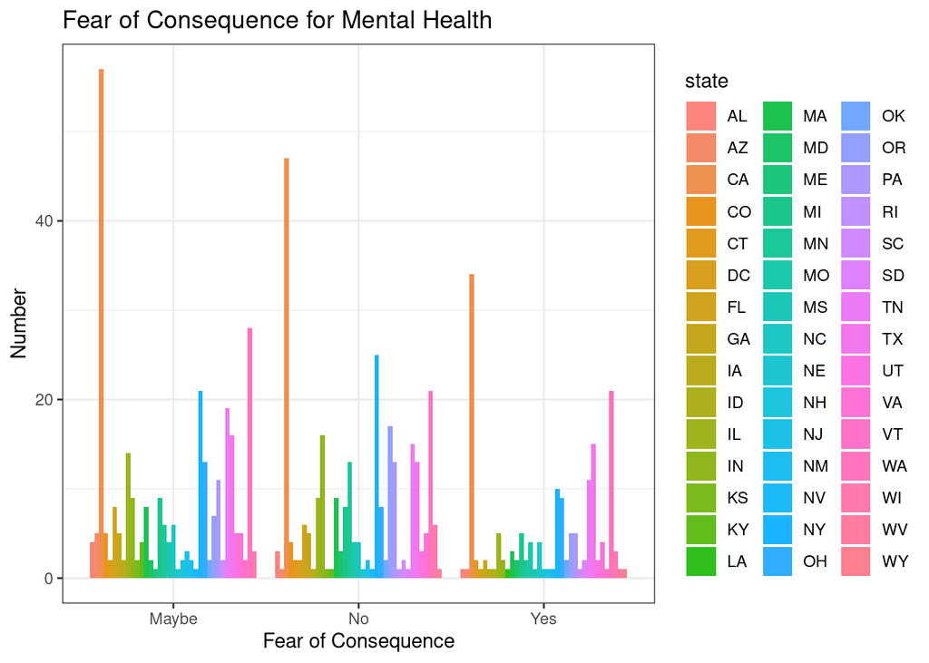

```r
MH_in_tech%>%
  filter(Country == "United States") %>%
  drop_na(state) %>%
  ggplot(aes(mental_health_consequence, fill = state))+
  geom_bar(position= "dodge", alpha = 0.89)  +
  theme_bw() + labs(title = "Fear of Consequence for Mental Health", x= "Fear of Consequence", y = "Number")
```

**YES=171 NO=280 MAYBE=300** Close to **23%** of employees responded to **YES** to the possibility of negative consequences for bringing up mental health with your employer. While almost **40%** answered **MAYBE.** With a little over **60%** between the two it goes to say that some employees may afraid to speak up if they think they may need help with mental health. Ultimately being afraid to speak up out of fear of negative consequence may cause detriment to employees.

**A graph and table showing the relation between the variables “Leave” and “State”.**

```r
table(MH_in_tech$state,MH_in_tech$leave)
```

```
##
##      Don't know Somewhat difficult Somewhat easy Very difficult Very easy
##   AL          4                  0             1              1         2
##   AZ          4                  0             3              0         0
##   CA         77                 14            20              8        19
##   CO          5                  1             1              0         2
##   CT          3                  0             0              0         1
##   DC          1                  0             2              0         1
##   FL          7                  2             0              3         3
##   GA          3                  4             3              1         1
##   IA          3                  0             1              0         0
##   ID          1                  0             0              0         0
##   IL         14                  4             4              3         4
##   IN         17                  0             7              0         3
##   KS          1                  0             0              2         0
##   KY          4                  0             1              0         0
##   LA          0                  0             0              1         0
##   MA         13                  2             2              0         3
##   MD          2                  0             1              1         4
##   ME          1                  0             0              0         0
##   MI         11                  2             5              3         1
##   MN         11                  1             3              0         6
##   MO          5                  1             2              1         3
##   MS          0                  0             1              0         0
##   NC         10                  1             2              0         1
##   NE          2                  0             0              0         0
##   NH          3                  0             0              0         0
##   NJ          3                  0             2              0         1
##   NM          2                  0             0              0         0
##   NV          2                  0             0              0         1
##   NY         33                  6             9              1         8
##   OH         15                  2             8              4         1
##   OK          4                  1             0              0         1
##   OR         18                  2             5              0         4
##   PA         12                  3             7              2         5
##   RI          1                  0             0              0         0
##   SC          0                  1             2              0         2
##   SD          2                  0             1              0         0
##   TN         22                  4            11              4         4
##   TX         21                  3            10              5         5
##   UT          2                  3             3              0         3
##   VA          8                  1             1              1         3
##   VT          3                  0             0              0         0
##   WA         27                  6            14             12        11
##   WI          2                  3             4              0         3
##   WV          0                  0             1              0         0
##   WY          2                  0             0              0         0
```

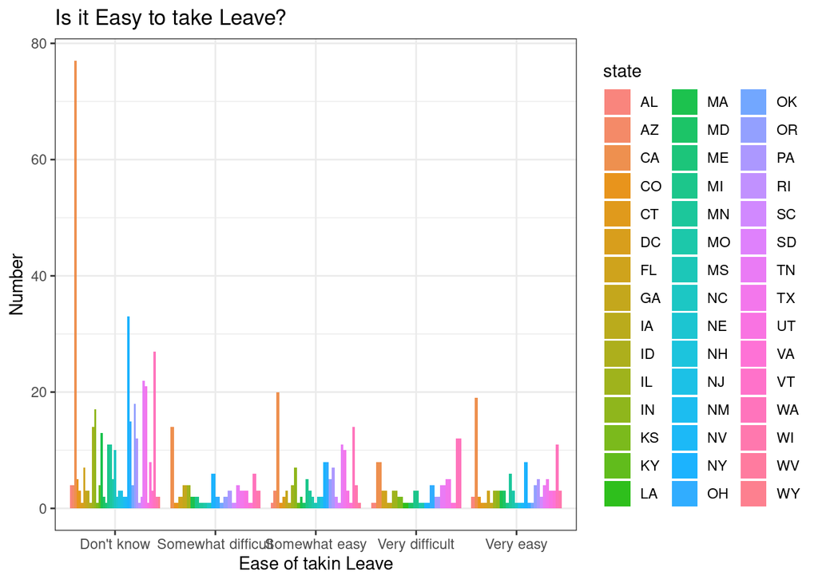

```r
MH_in_tech%>%
  filter(Country == "United States") %>%
  drop_na(state) %>%
  ggplot(aes(leave, fill = state))+
  geom_bar(position= "dodge", alpha = 0.89)  +
  theme_bw() + labs(title = "Is it Easy to take Leave?", x = "Ease of takin Leave", y = "Number")
```

**VERY EASY=108 VERY DIFFICULT=53 SOMEWHAT EASY=137 SOMEWHAT DIFFICULT=68 DON’T KNOW=385**

While only around **14%** of employees say it’s **Very Easy** to take leave for a mental health condition, a whopping **51%** don’t know. That’s not to say that they weren’t informed about how medical leave works. It could mean they’ve never needed to take any leave so they just aren’t informed on how it works. Meanwhile **16%** had some sort of difficulty trying to get medical leave, and although that’s not high it would be better if that percentage was lower as to not deter or make thing harder for employees who are already having a difficult time.

**A graph and table showing the relation between the variables “Supervisor” and “State”:**

```r
table(MH_in_tech$state,MH_in_tech$supervisor)
```

```
##
##      No Some of them Yes
##   AL  2            3   3
##   AZ  5            0   2
##   CA 46           44  48
##   CO  1            5   3
##   CT  2            1   1
##   DC  1            1   2
##   FL  4            5   6
##   GA  4            1   7
##   IA  2            1   1
##   ID  1            0   0
##   IL  9           11   9
##   IN  4            5  18
##   KS  0            0   3
##   KY  3            1   1
##   LA  0            1   0
##   MA  4            4  12
##   MD  3            0   5
##   ME  0            0   1
##   MI  8            8   6
##   MN  3            3  15
##   MO  5            2   5
##   MS  0            1   0
##   NC  5            6   3
##   NE  0            1   1
##   NH  0            2   1
##   NJ  2            1   3
##   NM  2            0   0
##   NV  1            1   1
##   NY 16           19  22
##   OH 14            8   8
##   OK  2            1   3
##   OR  6            7  16
##   PA 11            6  12
##   RI  0            0   1
##   SC  2            1   2
##   SD  1            1   1
##   TN 12            8  25
##   TX 18           12  14
##   UT  3            3   5
##   VA  3            4   7
##   VT  1            2   0
##   WA 23           23  24
##   WI  5            0   7
##   WV  1            0   0
##   WY  0            1   1
```

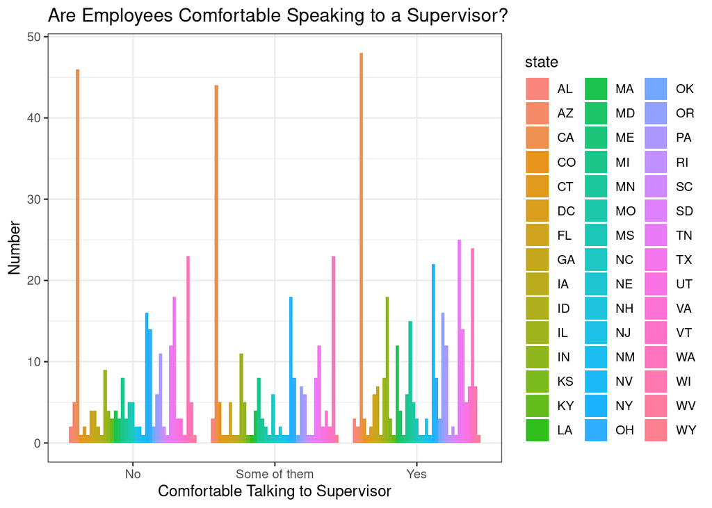

```r
MH_in_tech%>%
  filter(Country == "United States") %>%
  drop_na(state) %>%
  ggplot(aes(supervisor, fill = state))+
  geom_bar(position= "dodge", alpha = 0.89)  +
  theme_bw() + labs(title = "Are Employees Comfortable Speaking to a Supervisor?", x = "Comfortable Talking to Supervisor", y = "Number")
```

**YES=304 SOME OF THEM=209 NO=238** From the data above it shows that a little over **40%** of employees in the United States say that can or do feel comfortable going to their direct supervisor about their mental health. Which is great, feeling comfortable with your supervisor makes for better employees when they are feeling heard and seen, but there is always room for improvement.

**A bar graph and table showing the relation betwen variables, “Obs_Consequences” and “state”:**

```r
table(MH_in_tech$state,MH_in_tech$obs_consequence)
```

```
##
##       No Yes
##   AL   6   2
##   AZ   7   0
##   CA 122  16
##   CO   9   0
##   CT   3   1
##   DC   4   0
##   FL  12   3
##   GA  10   2
##   IA   3   1
##   ID   0   1
##   IL  24   5
##   IN  25   2
##   KS   3   0
##   KY   5   0
##   LA   0   1
##   MA  17   3
##   MD   7   1
##   ME   1   0
##   MI  18   4
##   MN  19   2
##   MO  11   1
##   MS   1   0
##   NC  14   0
##   NE   1   1
##   NH   2   1
##   NJ   6   0
##   NM   2   0
##   NV   3   0
##   NY  52   5
##   OH  26   4
##   OK   6   0
##   OR  28   1
##   PA  26   3
##   RI   1   0
##   SC   5   0
##   SD   3   0
##   TN  41   4
##   TX  37   7
##   UT  10   1
##   VA  13   1
##   VT   2   1
##   WA  56  14
##   WI  12   0
##   WV   1   0
##   WY   2   0
```

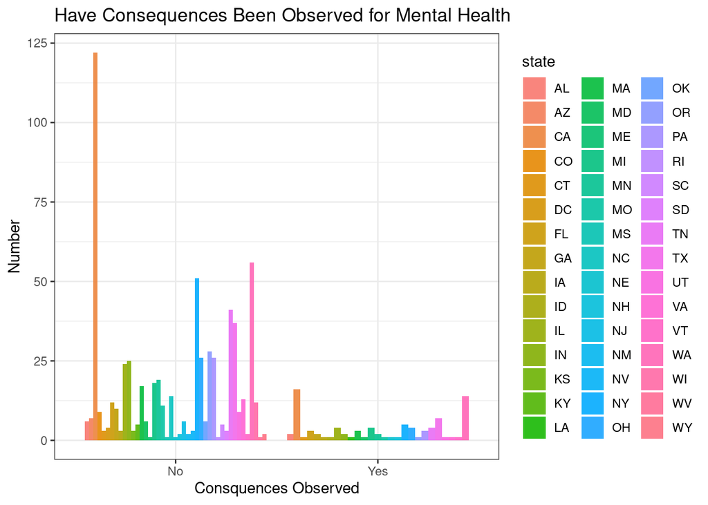

```r
MH_in_tech%>%
  filter(Country == "United States") %>%
  drop_na(state) %>%
  ggplot(aes(obs_consequence, fill = state))+
  geom_bar(position= "dodge", alpha = 0.89)  +
  theme_bw() + labs(title = "Have Consequences Been Observed for Mental Health ", x = "Consquences Observed", y= "Number")
```

**YES=89 NO=662** The data above shows that more than **85%** of employees in the US have **NOT** observed consequences to employees for speaking out about their mental health.

**A graph and table showing the relation between variables “mentalvsphysical” and “state”:**

```r
table(MH_in_tech$state,MH_in_tech$mental_vs_physical)
```

```
##
##      Don't know No Yes
##   AL          3  1   4
##   AZ          1  5   1
##   CA         58 39  41
##   CO          8  1   0
##   CT          3  1   0
##   DC          3  0   1
##   FL          8  3   4
##   GA          3  3   6
##   IA          4  0   0
##   ID          0  1   0
##   IL         15  6   8
##   IN         18  2   7
##   KS          1  2   0
##   KY          4  1   0
##   LA          0  1   0
##   MA         11  4   5
##   MD          5  1   2
##   ME          0  1   0
##   MI         10  8   4
##   MN          9  4   8
##   MO          6  4   2
##   MS          1  0   0
##   NC          6  3   5
##   NE          1  1   0
##   NH          1  1   1
##   NJ          4  1   1
##   NM          2  0   0
##   NV          2  1   0
##   NY         31  7  19
##   OH         14 12   4
##   OK          1  3   2
##   OR         18  3   8
##   PA         12  9   8
##   RI          1  0   0
##   SC          3  0   2
##   SD          1  0   2
##   TN         25 13   7
##   TX         22 15   7
##   UT          5  4   2
##   VA          5  2   7
##   VT          3  0   0
##   WA         26 19  25
##   WI          3  2   7
##   WV          0  1   0
##   WY          2  0   0
```

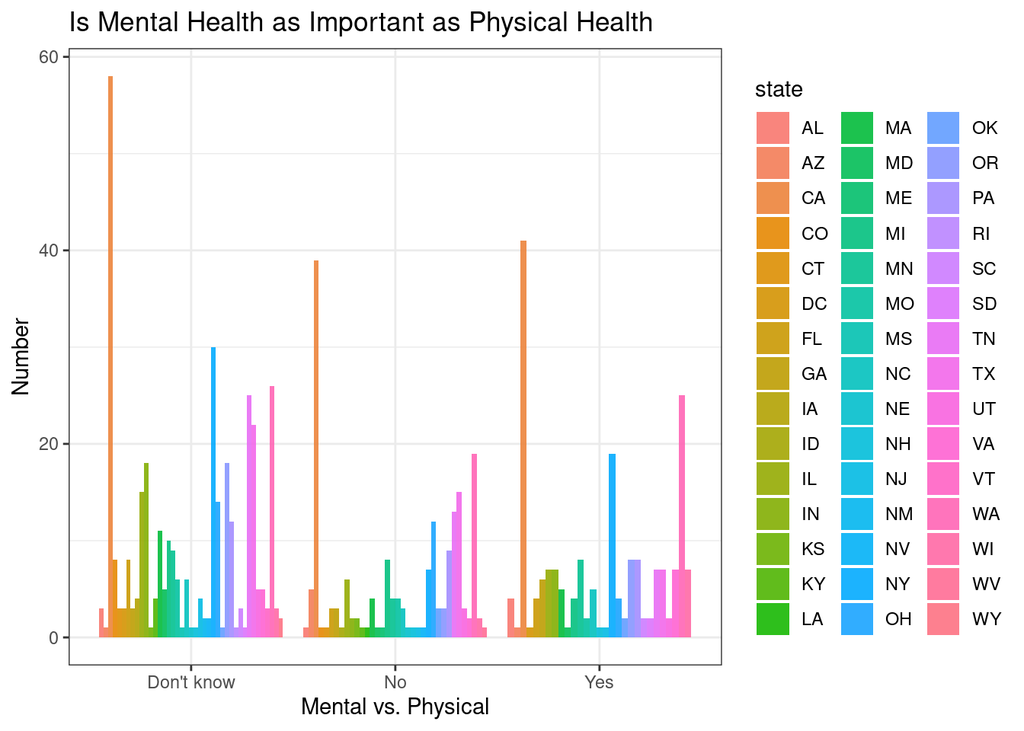

```r
MH_in_tech%>%
  filter(Country == "United States") %>%
  drop_na(state) %>%
  ggplot(aes(mental_vs_physical, fill = state))+
  geom_bar(position= "dodge", alpha = 0.89)  +
  theme_bw() + labs(title = "Is Mental Health as Important as Physical Health", x = "Mental vs. Physical", y = "Number")
```

**YES=201 NO=187 DON’T KNOW=363** From the data above, a little more than **26%** of the of employees in the United States say that their employers take their mental health as important as their physical health. While that is a little over a quarter of the responses just a little less than **25%** say that their employers don’t take it as seriously, and a just over **48%** don’t know if their employer takes mental health as seriously physical health. When getting a job employers always make an effort to include benefits, and one of them being medical insurance. A good way to let employees know that mental health is taken seriously is also covering therapy, or other types of mental care so employees know that it is just as necessary as physical care.

**A graph and table showing the relation between variables “anonymity” and “state”:**

```r
table(MH_in_tech$state, MH_in_tech$anonymity)
```

```
##
##      Don't know No Yes
##   AL          4  1   3
##   AZ          3  0   4
##   CA         97  1  40
##   CO          4  0   5
##   CT          3  0   1
##   DC          3  0   1
##   FL          9  2   4
##   GA          5  0   7
##   IA          4  0   0
##   ID          1  0   0
##   IL         17  3   9
##   IN         18  0   9
##   KS          3  0   0
##   KY          3  0   2
##   LA          0  0   1
##   MA         12  0   8
##   MD          4  0   4
##   ME          1  0   0
##   MI         14  1   7
##   MN         14  0   7
##   MO          8  0   4
##   MS          0  0   1
##   NC          9  0   5
##   NE          1  0   1
##   NH          3  0   0
##   NJ          5  0   1
##   NM          2  0   0
##   NV          3  0   0
##   NY         38  1  18
##   OH         23  1   6
##   OK          4  1   1
##   OR         21  0   8
##   PA         17  0  12
##   RI          1  0   0
##   SC          4  0   1
##   SD          1  0   2
##   TN         34  1  10
##   TX         30  3  11
##   UT          7  0   4
##   VA          9  0   5
##   VT          3  0   0
##   WA         40  2  28
##   WI          6  0   6
##   WV          0  1   0
##   WY          2  0   0
```

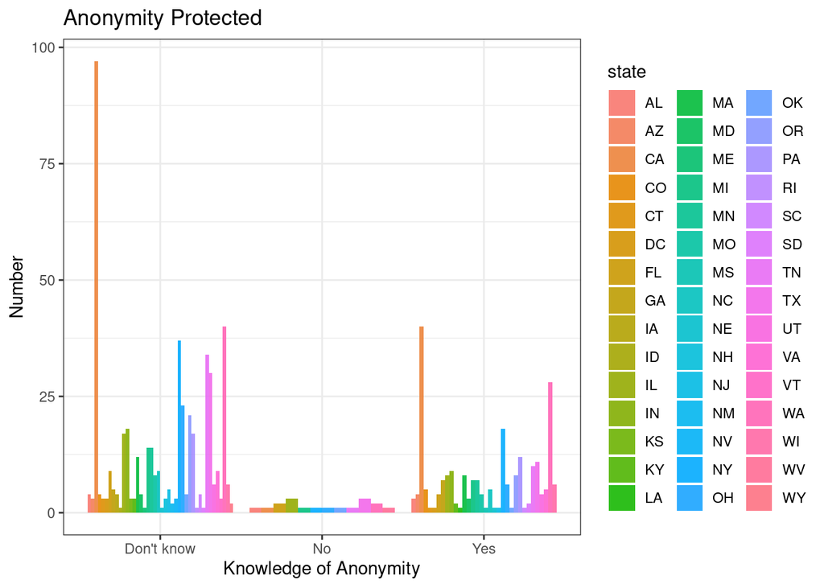

```r
MH_in_tech%>%
  filter(Country == "United States") %>%
  drop_na(state) %>%
  ggplot(aes(anonymity, fill = state))+
  geom_bar(position= "dodge", alpha = 0.89)  +
  theme_bw() + labs(title = "Anonymity Protected", x = "Knowledge of Anonymity",  y = "Number" )
```

**NO=19 YES=237 DON’T KNOW=495**

With close to **66%** of employees not knowing if they’re anonymity is protected if they came forward with mental health concerns or substance abuse issues, the likelihood that they would come forward is lessened with the possible fear that there may be negative consequence in asking for help.

**A graph and table showing the relation between variables, “family_history” and “state”:**

```r
table(MH_in_tech$state,MH_in_tech$family_history)
```

```
##
##      No Yes
##   AL  3   5
##   AZ  4   3
##   CA 70  68
##   CO  7   2
##   CT  3   1
##   DC  2   2
##   FL 11   4
##   GA  6   6
##   IA  3   1
##   ID  0   1
##   IL 14  15
##   IN 15  12
##   KS  3   0
##   KY  4   1
##   LA  1   0
##   MA 15   5
##   MD  5   3
##   ME  0   1
##   MI 13   9
##   MN 12   9
##   MO  5   7
##   MS  1   0
##   NC  7   7
##   NE  1   1
##   NH  1   2
##   NJ  4   2
##   NM  2   0
##   NV  3   0
##   NY 35  22
##   OH 21   9
##   OK  4   2
##   OR 15  14
##   PA 13  16
##   RI  1   0
##   SC  4   1
##   SD  2   1
##   TN 18  27
##   TX 31  13
##   UT  7   4
##   VA  9   5
##   VT  2   1
##   WA 35  35
##   WI  5   7
##   WV  1   0
##   WY  1   1
```

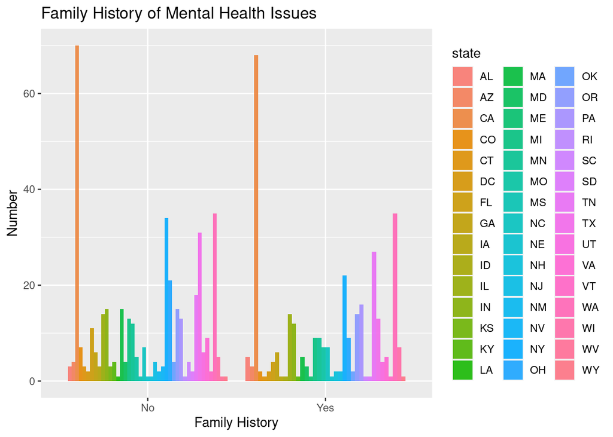

```r
MH_in_tech%>%
  filter(Country == "United States") %>%
  drop_na(state) %>%
  ggplot(aes(family_history, fill = state))+
  geom_bar(position= "dodge", alpha = 0.89) + labs(title = "Family History of Mental Health Issues", x = "Family History", y = "Number")
```

**NO=421 YES=330** More than **55%** of employees have answered no to having having a family history of mental health issues, while just under **44%** answered yes to mental health running in their family. With a number that high it seems that employers should try and include mental health resources in their employees benefits package. Although majority of this demographic said no to it running in the family, having the resources available to you may put employees at ease if they ever do need to use them.

**A graph and table showing the relation between variables, “work_interfere” and “state”:**

```r
table(MH_in_tech$state, MH_in_tech$work_interfere)
```

```
##
##      Never Often Rarely Sometimes
##   AL     1     1      0         6
##   AZ     0     1      1         3
##   CA    20    19     19        59
##   CO     5     0      2         1
##   CT     1     1      1         0
##   DC     1     0      0         1
##   FL     3     3      2         4
##   GA     5     1      0         5
##   IA     1     1      0         1
##   ID     0     0      0         1
##   IL     3     5      7        11
##   IN     6     2      4         9
##   KS     2     0      0         0
##   KY     1     1      1         0
##   LA     0     0      0         1
##   MA     4     4      4         4
##   MD     1     0      1         3
##   ME     0     0      0         1
##   MI     3     0      3        12
##   MN     5     1      4         6
##   MO     3     2      3         0
##   MS     0     1      0         0
##   NC     1     0      2         8
##   NE     1     0      0         1
##   NH     1     0      0         2
##   NJ     1     1      0         3
##   NM     0     0      0         0
##   NV     1     0      0         1
##   NY     8     6      9        18
##   OH     3     3      3        18
##   OK     1     1      1         1
##   OR     4     1      6        12
##   PA     5     2     10         9
##   RI     0     0      0         0
##   SC     1     0      1         1
##   SD     0     0      1         2
##   TN     7     6      4        14
##   TX     7     5      6        18
##   UT     1     2      3         4
##   VA     5     2      0         6
##   VT     1     0      0         0
##   WA    10     8      9        32
##   WI     0     2      2         7
##   WV     0     0      0         1
##   WY     0     0      0         2
```

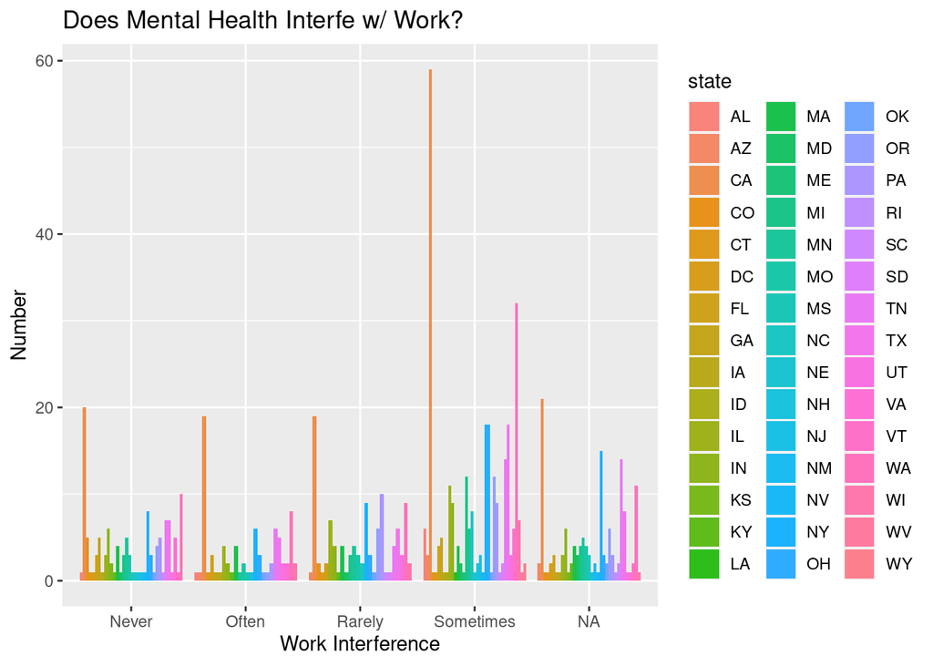

```r
MH_in_tech%>%
  filter(Country == "United States") %>%
  drop_na(state) %>%
  ggplot(aes(work_interfere, fill = state))+
  geom_bar(position= "dodge", alpha = 0.89) + labs(title = "Does Mental Health Interfe w/ Work?", x = "Work Interference", y = "Number")
```

**NEVER=125 OFTEN=82 RARELY=111 SOMETIMES=289 NA=144** Out of the 751 observations coming from the United States, 144 of them were N/A in this variable leaving almost **20%** of the data not counting directly to the responses. With combination of slightly over **31%**, 236 employees responded that their mental health condition **NEVER** or **RARELY** interferes with their work. Meanwhile almost **50%** of employees responded that their mental health conditions **SOMETIMES** or **OFTEN** interferes with their work. Witht hat kind of margin, having a supervisor you can talk to about said issues may be able to alleviate some stress, and help in finding out what resources may be available to help cope.

**A graph and table showing the relation between variables, “care_options” and “state”:**

```r
table(MH_in_tech$state,MH_in_tech$care_options)
```

```
##
##      No Not sure Yes
##   AL  3        1   4
##   AZ  1        0   6
##   CA 44       40  54
##   CO  1        2   6
##   CT  2        1   1
##   DC  2        0   2
##   FL  7        3   5
##   GA  2        3   7
##   IA  2        2   0
##   ID  0        0   1
##   IL  7        7  15
##   IN 10        7  10
##   KS  1        1   1
##   KY  2        1   2
##   LA  1        0   0
##   MA  4        5  11
##   MD  2        4   2
##   ME  1        0   0
##   MI  8        8   6
##   MN  9        4   8
##   MO  6        5   1
##   MS  1        0   0
##   NC  4        4   6
##   NE  0        1   1
##   NH  0        1   2
##   NJ  2        1   3
##   NM  2        0   0
##   NV  1        0   2
##   NY 14       15  28
##   OH 13        6  11
##   OK  2        3   1
##   OR  9       10  10
##   PA  7        7  15
##   RI  1        0   0
##   SC  2        0   3
##   SD  1        1   1
##   TN 17       14  14
##   TX 19       10  15
##   UT  5        1   5
##   VA  3        6   5
##   VT  0        2   1
##   WA 18       18  34
##   WI  1        2   9
##   WV  1        0   0
##   WY  1        0   1
```

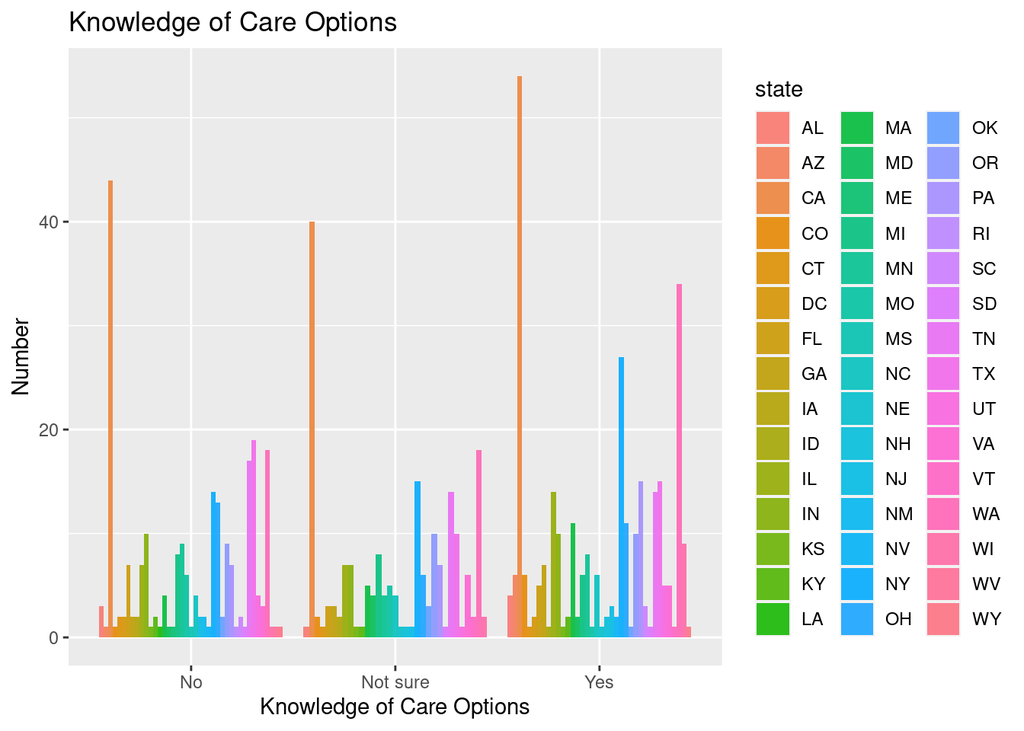

```r
MH_in_tech%>%
  filter(Country == "United States") %>%
  drop_na(state) %>%
  ggplot(aes(care_options, fill = state))+
  geom_bar(position= "dodge", alpha = 0.89) + labs(title = "Knowledge of Care Options", x = "Knowledge of Care Options", y = "Number")
```

**NO=239 NOT SURE=201 YES=311**

Over **40%** of employees responded **YES** to knowing what care options their employers provide when it comes to mental health. With that being said almost **59%** either don’t know their care options for mental health or are unclear on what they are.

### *Although it seems that we’re make large strides for mental health in the workplace as a country, it looks like their are still some efforts to be made. A lot of employees seem to NOT know what’s available to them in regards to mental health at work. One can make the assumption that they were not informed, or not informed well enough. Employers for new hires and even current employees could make more of an effort in letting their employees know what their benefits package include, for both medical care and mental health care.*

### *Allowing your employees to come to you when they are feeling mentally unwell, without fear of negative consequence leaves the door open for employees to feel safe and get the help the need to continue to do great work. Monthly or quarterly check ins on mental health with employees gives the impression that they are more than a number, and that you care about who they are as person behind all the work they do for company.*